# NBA 2014-2017 Season Player Metrics Analysis by Esam Rhman

> This analysis will explore NBA players season standard (per 36 minutes) and advanced stats for the 2014-2017 NBA seasons

# Univariate Plots Section

```
## 'data.frame':    2469 obs. of  48 variables:
##  $ Season  : int  2017 2017 2017 2017 2017 2017 2017 2017 2017 2017 ...
##  $ Player  : Factor w/ 786 levels "A.J. Hammons",..: 15 610 695 58 53 132 463 333 421 724 ...
##  $ Pos     : Factor w/ 13 levels "C","G","PF","PF-C",..: 11 3 1 1 11 1 1 1 6 8 ...
##  $ Age     : int  24 27 24 20 32 29 32 19 25 36 ...
##  $ Tm      : Factor w/ 31 levels "ATL","BOS","BRK",..: 21 3 21 16 22 18 27 3 2 19 ...
##  $ G       : int  71 64 71 65 51 19 69 66 12 22 ...
##  $ GS      : int  8 8 71 19 3 0 69 25 0 0 ...
##  $ MP      : int  1054 1244 2321 1304 657 46 2299 1291 39 273 ...
##  $ FG      : num  3.7 3.3 6.5 4.6 3.3 3.9 9.8 5.9 0.9 5.8 ...
##  $ FGA     : num  9.4 9.5 10.4 8.9 8.4 11.7 19.3 10.2 5.5 12 ...
##  $ FG_PERC : num  0.398 0.348 0.628 0.514 0.392 0.333 0.508 0.584 0.167 0.484 ...
##  $ X3P     : num  2.7 2.6 0 0 1.4 0 0.4 0.1 0 0.5 ...
##  $ X3PA    : num  7 7.6 0 0.2 3.6 0 1.4 0.4 2.8 1.6 ...
##  $ X3P_PERC: num  0.388 0.341 0 0 0.385 NA 0.31 0.231 0 0.333 ...
```

[output cut: 34 more lines]

```
##      Season                 Player          Pos           Age
##  Min.   :2014   Ersan Ilyasova :  11   SG     :532   Min.   :19.00
##  1st Qu.:2014   Corey Brewer   :  10   PG     :525   1st Qu.:23.00
##  Median :2016   Sean Kilpatrick:  10   PF     :513   Median :26.00
##  Mean   :2015   Brandan Wright :   9   SF     :446   Mean   :26.48
##  3rd Qu.:2017   Briante Weber  :   9   C      :438   3rd Qu.:29.00
##  Max.   :2017   Jameer Nelson  :   9   PG-SG  :  3   Max.   :41.00
##                 (Other)        :2411   (Other): 12
##        Tm             G               GS              MP
##  TOT    : 235   Min.   : 1.00   Min.   : 0.00   Min.   :   0
##  NOP    :  91   1st Qu.:22.00   1st Qu.: 0.00   1st Qu.: 272
##  MEM    :  87   Median :51.00   Median : 7.00   Median : 895
##  PHI    :  87   Mean   :46.09   Mean   :21.11   Mean   :1039
##  PHO    :  86   3rd Qu.:70.00   3rd Qu.:37.00   3rd Qu.:1687
##  DAL    :  82   Max.   :83.00   Max.   :82.00   Max.   :3125
##  (Other):1801
##        FG              FGA           FG_PERC            X3P
##  Min.   : 0.000   Min.   : 0.00   Min.   :0.0000   Min.   : 0.000
##  1st Qu.: 4.000   1st Qu.: 9.50   1st Qu.:0.3960   1st Qu.: 0.200
##  Median : 5.100   Median :11.60   Median :0.4360   Median : 1.100
##  Mean   : 5.161   Mean   :11.85   Mean   :0.4372   Mean   : 1.225
##  3rd Qu.: 6.300   3rd Qu.:14.00   3rd Qu.:0.4830   3rd Qu.: 1.900
##  Max.   :36.000   Max.   :36.00   Max.   :1.0000   Max.   :36.000
##  NA's   :1        NA's   :1       NA's   :13       NA's   :1
##       X3PA           X3P_PERC           X2P              X2PA
##  Min.   : 0.000   Min.   :0.0000   Min.   : 0.000   Min.   : 0.000
##  1st Qu.: 1.300   1st Qu.:0.2500   1st Qu.: 2.600   1st Qu.: 5.700
##  Median : 3.700   Median :0.3330   Median : 3.800   Median : 7.900
##  Mean   : 3.683   Mean   :0.2979   Mean   : 3.936   Mean   : 8.168
##  3rd Qu.: 5.500   3rd Qu.:0.3750   3rd Qu.: 5.100   3rd Qu.:10.200
##  Max.   :36.000   Max.   :1.0000   Max.   :18.000   Max.   :36.000
##  NA's   :1        NA's   :243      NA's   :1        NA's   :1
##     X2P_PERC            FT             FTA            FT_PERC
##  Min.   :0.0000   Min.   : 0.00   Min.   : 0.000   Min.   :0.0000
##  1st Qu.:0.4360   1st Qu.: 1.20   1st Qu.: 1.700   1st Qu.:0.6670
##  Median :0.4810   Median : 1.90   Median : 2.700   Median :0.7600
##  Mean   :0.4791   Mean   : 2.24   Mean   : 3.045   Mean   :0.7369
##  3rd Qu.:0.5290   3rd Qu.: 3.00   3rd Qu.: 4.000   3rd Qu.:0.8297
##  Max.   :1.0000   Max.   :28.80   Max.   :36.000   Max.   :1.0000
##  NA's   :35       NA's   :1       NA's   :1        NA's   :127
```

[output cut: 41 more lines]

```
##  Min.   :-3.300   Min.   :-0.20   Min.   :-2.100   Min.   :-1.06000
##  1st Qu.: 0.000   1st Qu.: 0.20   1st Qu.: 0.200   1st Qu.: 0.03400
##  Median : 0.500   Median : 0.70   Median : 1.300   Median : 0.08000
##  Mean   : 1.099   Mean   : 1.04   Mean   : 2.141   Mean   : 0.07223
##  3rd Qu.: 1.700   3rd Qu.: 1.60   3rd Qu.: 3.300   3rd Qu.: 0.11800
##  Max.   :13.800   Max.   : 6.00   Max.   :17.900   Max.   : 2.71400
##                                                    NA's   :1
##       OBPM              DBPM               BPM               VORP
##  Min.   :-39.000   Min.   :-20.0000   Min.   :-58.900   Min.   :-1.4000
##  1st Qu.: -3.000   1st Qu.: -1.8000   1st Qu.: -3.800   1st Qu.:-0.1000
##  Median : -1.200   Median : -0.5000   Median : -1.600   Median : 0.0000
##  Mean   : -1.509   Mean   : -0.5288   Mean   : -2.037   Mean   : 0.4908
##  3rd Qu.:  0.200   3rd Qu.:  0.8000   3rd Qu.:  0.300   3rd Qu.: 0.7000
##  Max.   : 68.800   Max.   : 17.1000   Max.   : 54.500   Max.   :12.4000
##
```

> The dataset contains 48 variables and 2469 observations, of the 48 variables 4 are categorical. A few things that jumps out. First of all it would make sense to convert the discrete Season and Pos variables into Factors. Also there seems to be at least 1 entry of 0 MP (minutes played), which clearly isn’t enough volume to produce meaningful NBA stats. Investigating further:

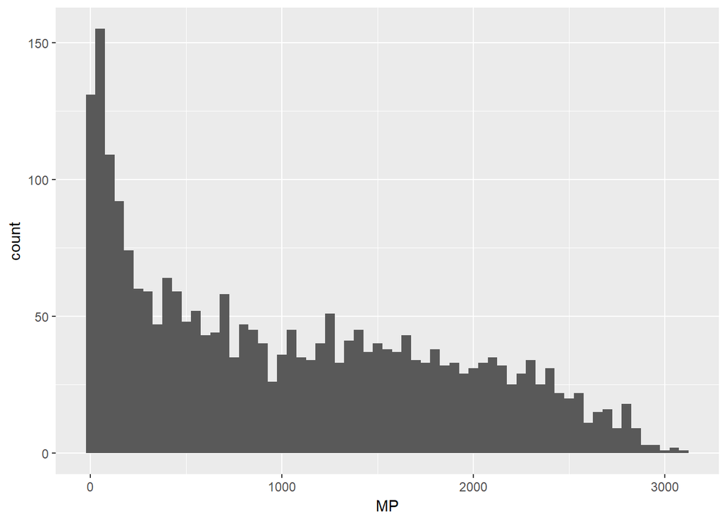

> We can see there are quite a few low MP entries. In order to only include season stats based on meaningful MPs, I will subset the dataset for only entries with at least 250 minutes played. I’ll also perform the Factor conversion mentioned earlier.

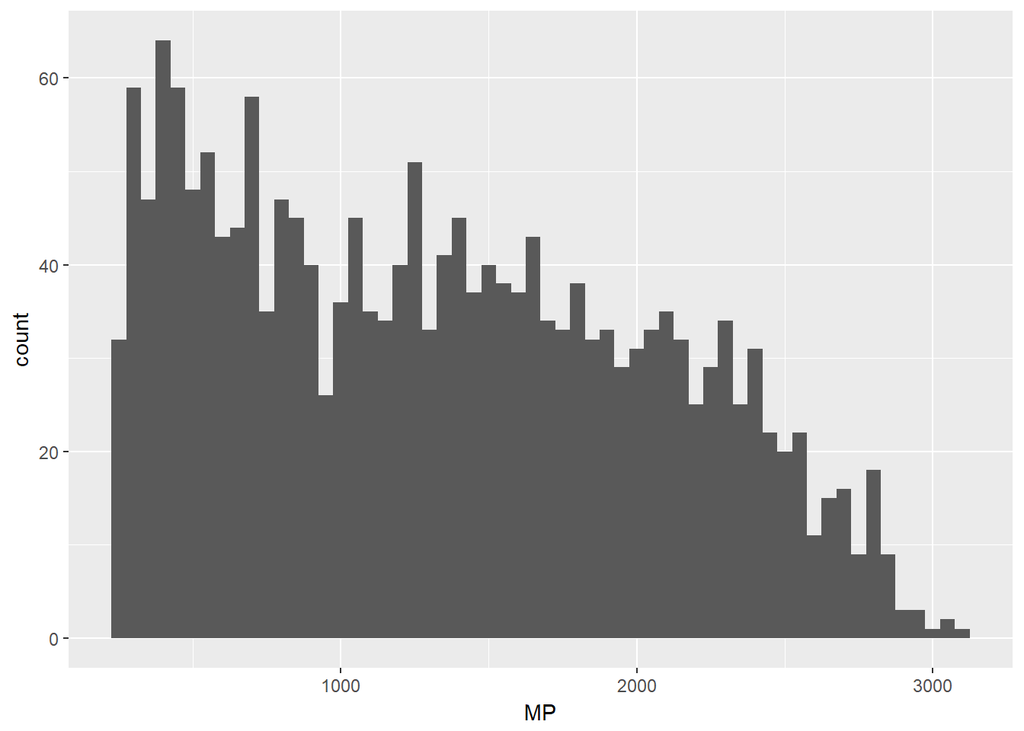

```
##    Min. 1st Qu.  Median    Mean 3rd Qu.    Max.
##   251.0   693.5  1277.5  1335.1  1906.2  3125.0
```

> Much better.

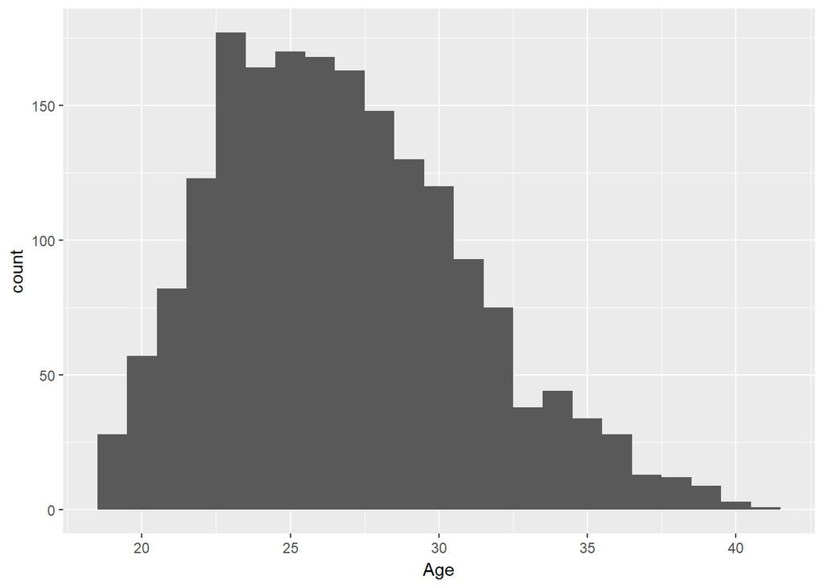

> Looks like we have a roughly normal distribution for Age with a slight positive skew. The median looks to be roughly around 25 years old. We also have a few players with seasons played as 40+ year olds.

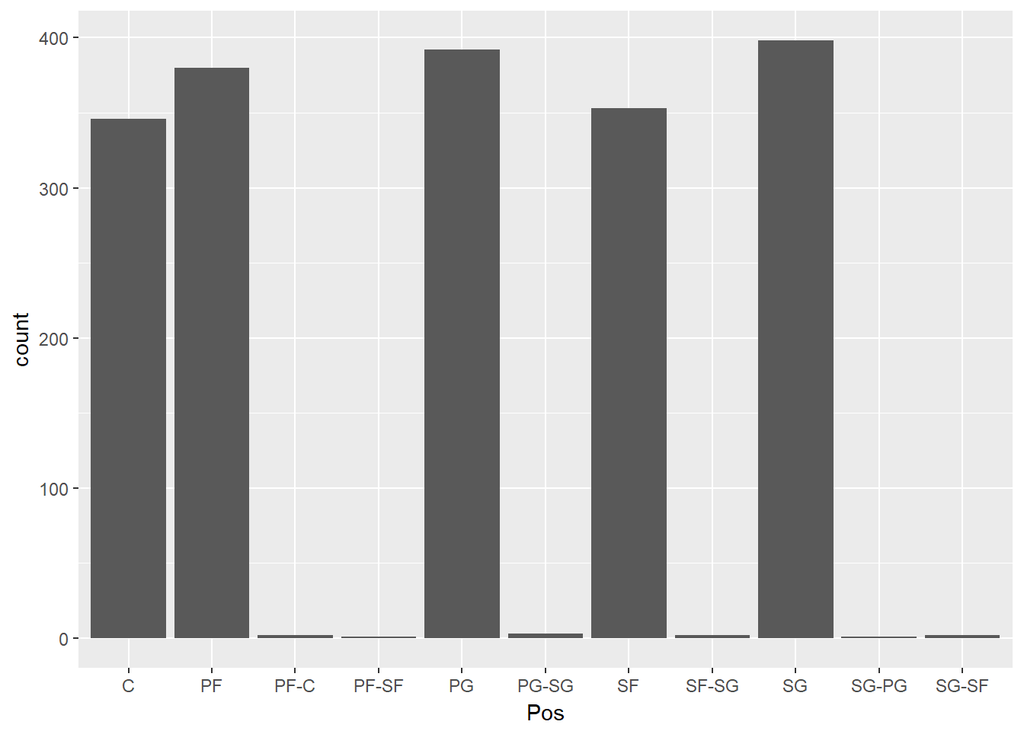

> There are a few hybrid positions in our Pos variable. Positions provides an important context when looking at the rest of the stats, to clean it up I will replace the hybrid values with the Pos value to the left of the dash

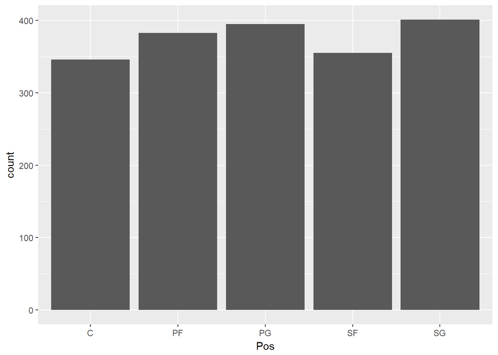

> Much cleaner. It looks like the league had generally more guards than forwards the past 4 seasons, the largest number of players being SGs while Cs being the most scarce. It should be noted this is only based on players playing more at least 250 mins. Lets see if this trend has been the same across all 4 seasons:

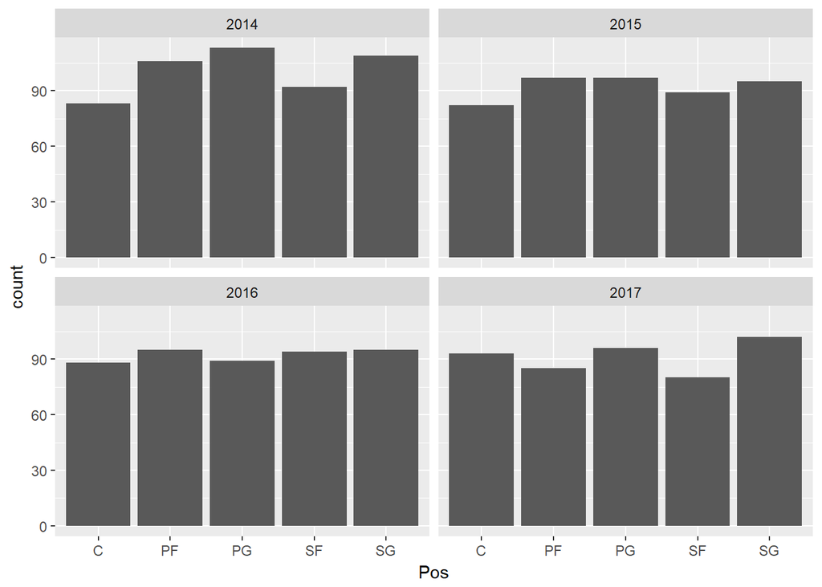

> Interesting observations emerge when looking at the positions by season. The number of guards relative to the other positions seems to have been decreasing over the last 4 seasons, with SGs making a bit of rebound in 2017. The number of Centers relative to the other positions also seem to have been steadily increasing over the 4 seasons, surpassing PFs and SFs in 2017 and approaching PG totals. The distribtion of positions has certainly not been static over the last 4 seasons

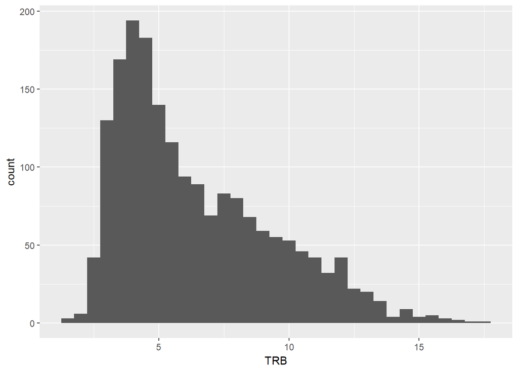

> The distribution of TRB (Total Rebounds per 36 mins) seems to be positively skewed, it would be interesting to see this in context of the different positions.

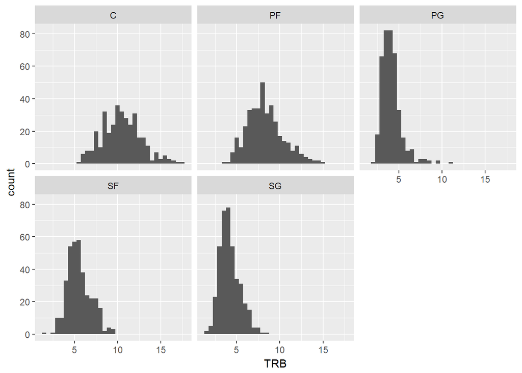

> There is a clear variance in the distribution across the different positions, Centers (C) and Power Forwards (PF) produce a more normal distribution than the other positions

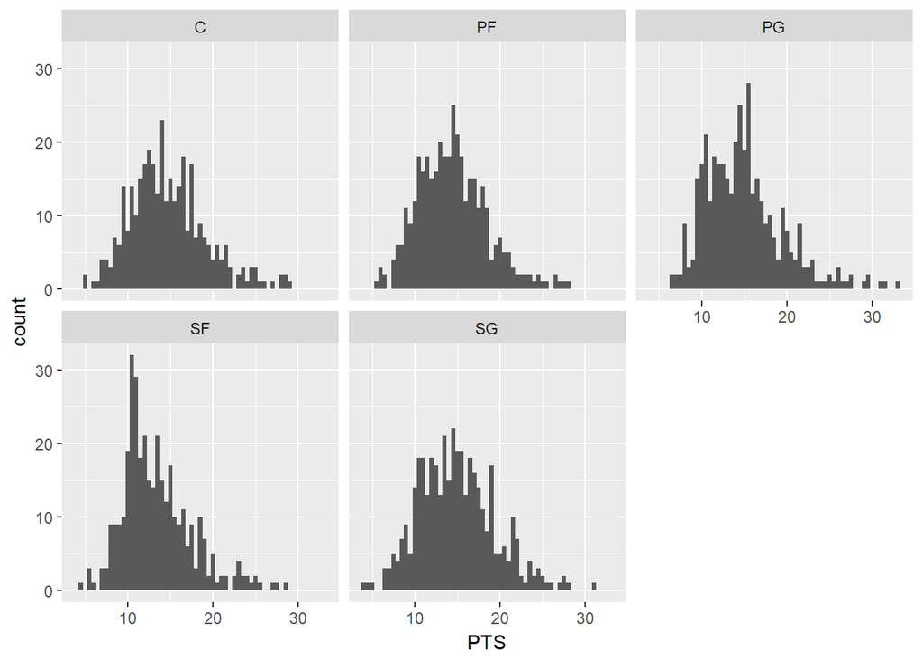

> The distribution of (Points per 36 minutes) is mostly normal for all positions except SF, in which its positively skewed.

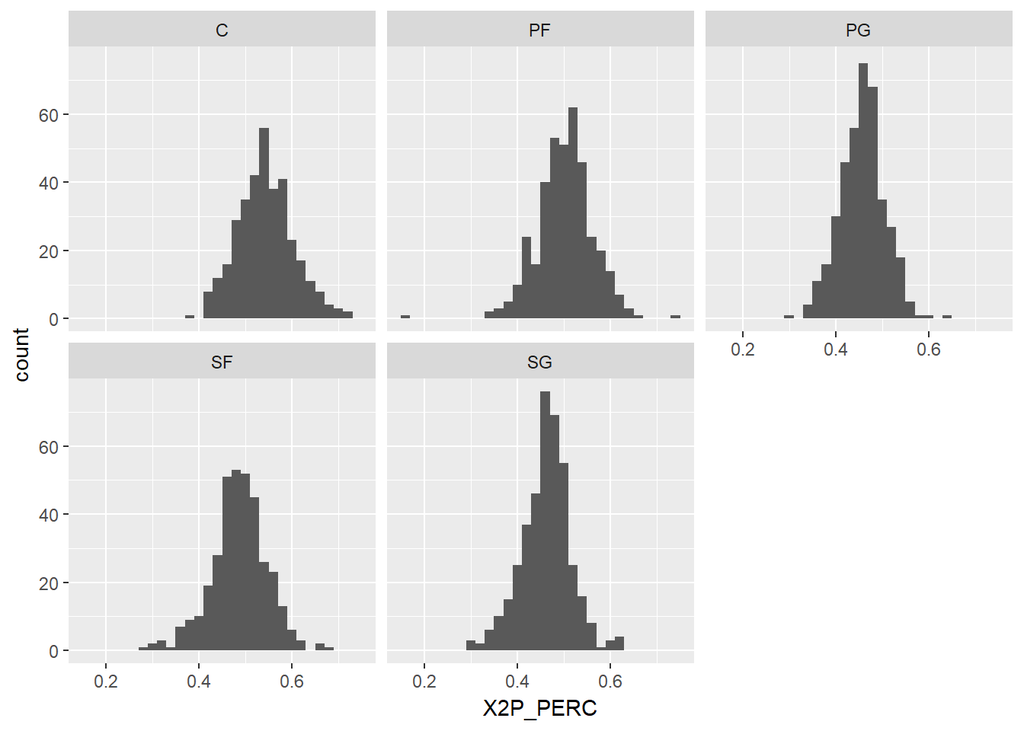

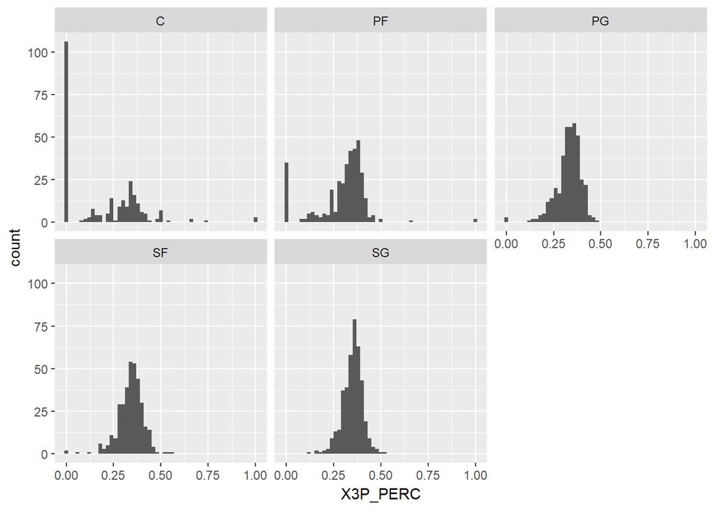

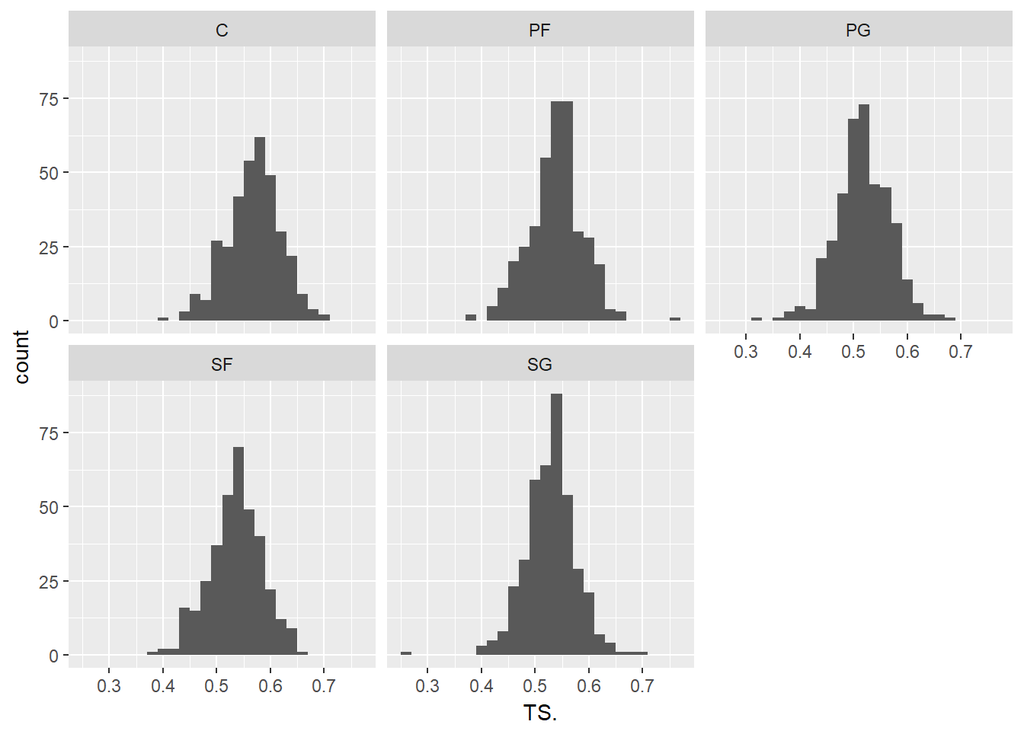

> Comparing the standard Shooting % stats (X2P_PERC/X3P_PERC) vs the advanced True Shooting % metric(TS.), which takes into account that 3 pointers are worth more than 2 pointers, produces interesting results. Centers and PFs have a higher median than other positions when just looking at 2 pointer shooting %, however based on the X3P_PERC distribution Centers struggle when it comes to 3 point shooting %. However with the True Shooting % (TS.), the distributions become very similiar across the different positinos, taking a normal distribution shape. Another observation is the huge spike in 0% X3P_PERC for centers, I suspect this is due to an extremely low number of attempts. I’ll subset the data set for that plot to include at least 0.5 X3PA (3 point attempt per 36 mins)

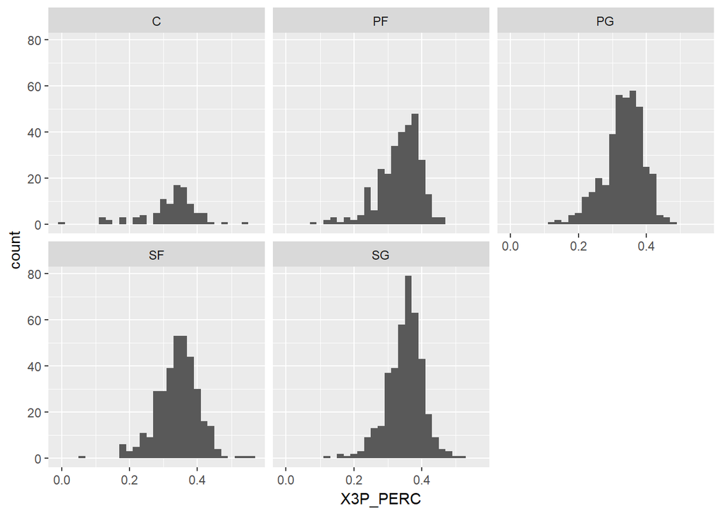

>That confirms it

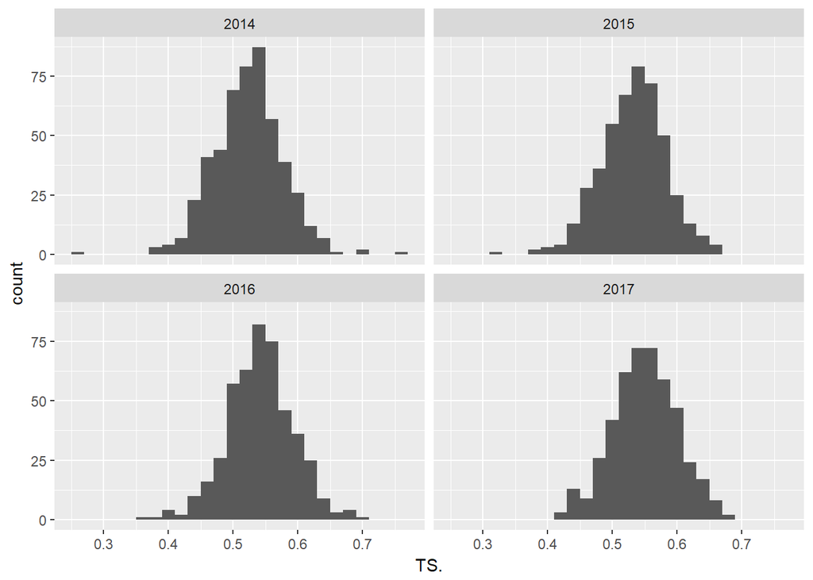

> Observing True Shooting % by season yeilds more interesting results. It seems that this metric has been steadily improving over the last 4 seasons. This could have something to do with teams beginning to increasingly incorporate analytics into the game. One indication of this could be the trend of 3 point attempts (X3PA), lets look in to that.

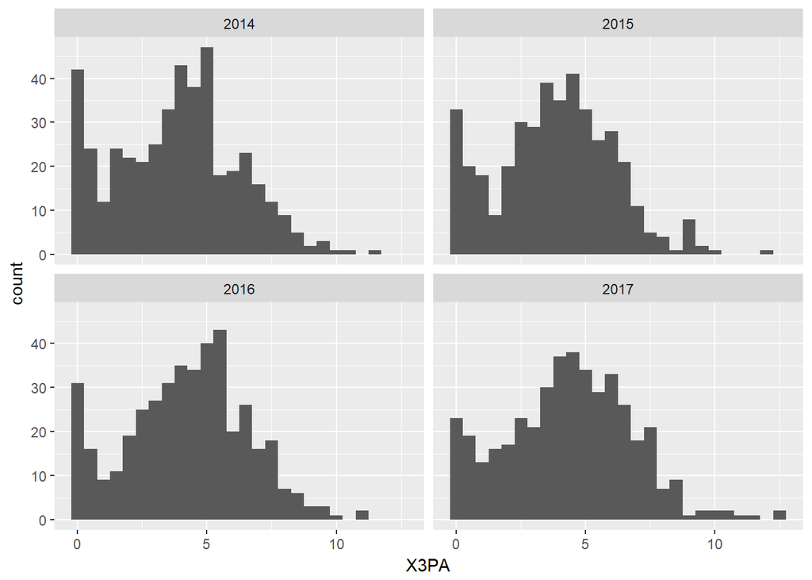

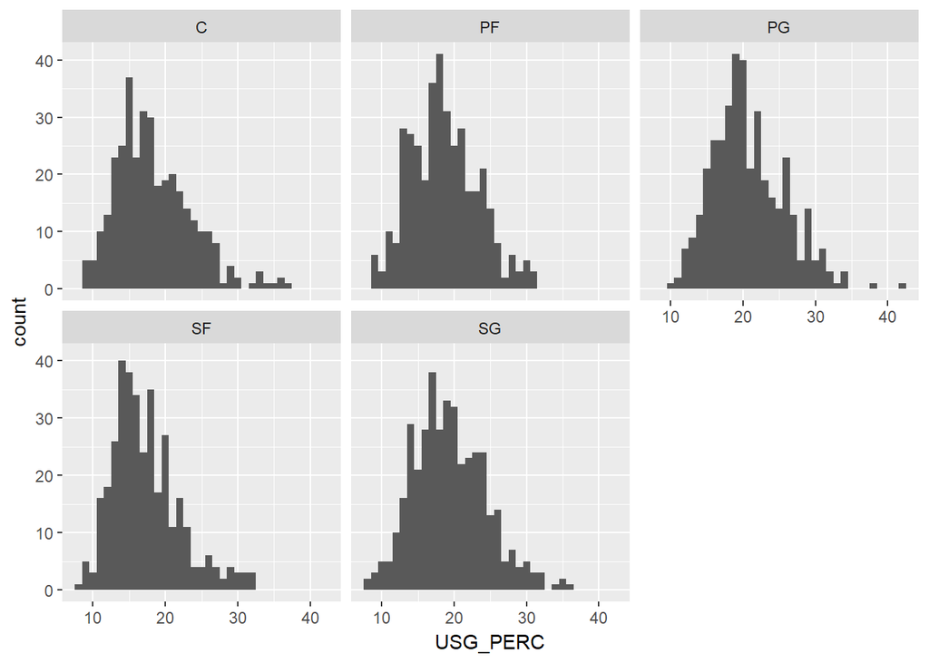

> Another interesting advanced metric is Usage % (USG_PERC), however nothing particularly stands out when looking at the distribution. SF do seem to have a slightly more postively skewed distribution than the other positions but not by much.

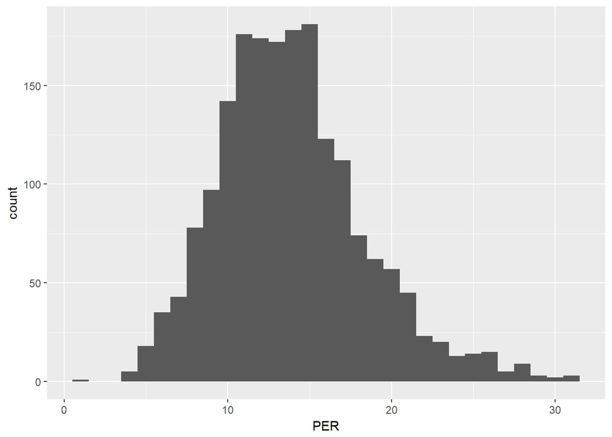

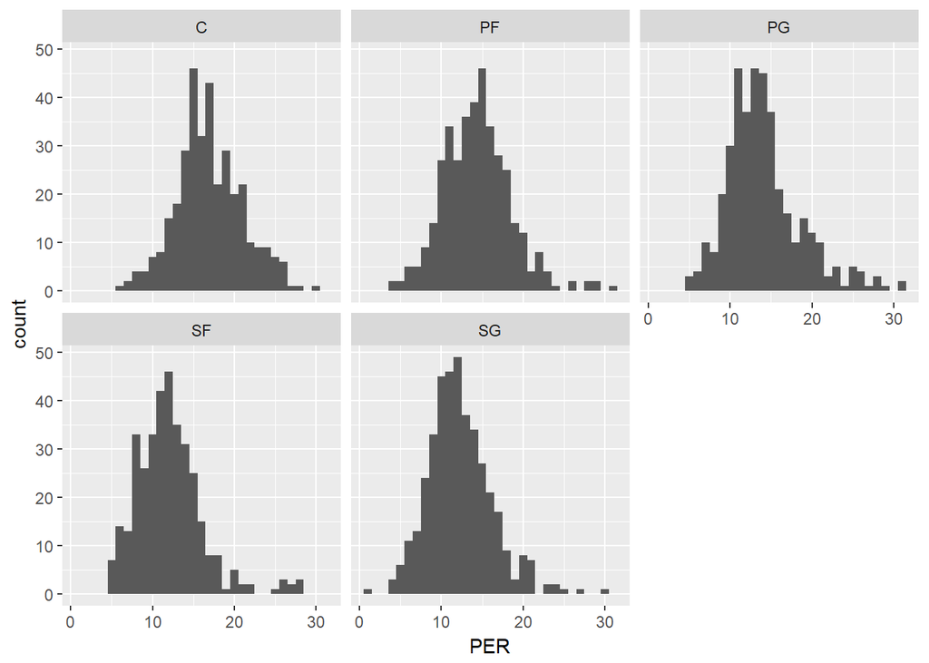

> One of the most commonly used advanced metrics is PER (Player Efficiency Rating). While the distribution seem normal for all positions, Cs and PFs seem to have a slightly higher median PER than the other 3 positions.

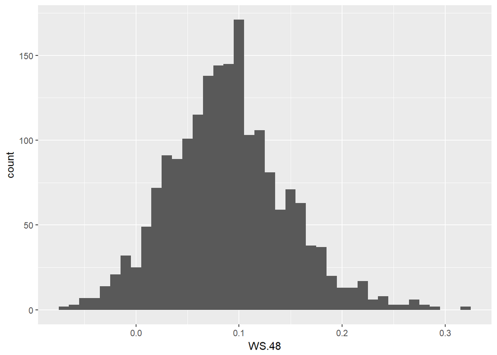

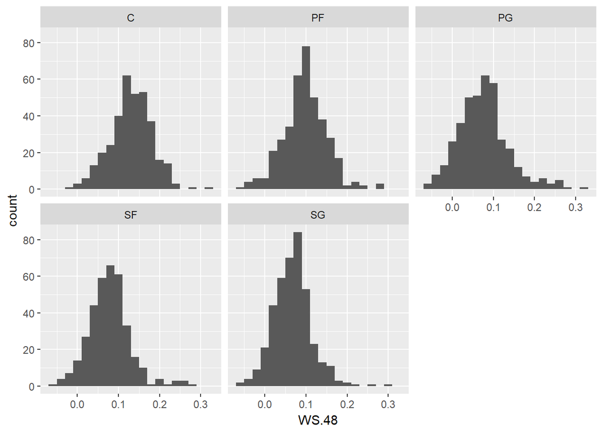

> Win Share per 48 minutes(WS.48) is arguably one of the most effective metrics of measuring players performance in terms of actual wins for their respective teams. The distribution looks similar across the SG, PF, and SF positions, its mostly a normal distribution. That said the C position has a higher median than the aforementioned 3 positions while PGs seems to have a lower median. This indicates centers generally contribute more to their team wins than other positions, an interesting observation that warrants a deeper dive.

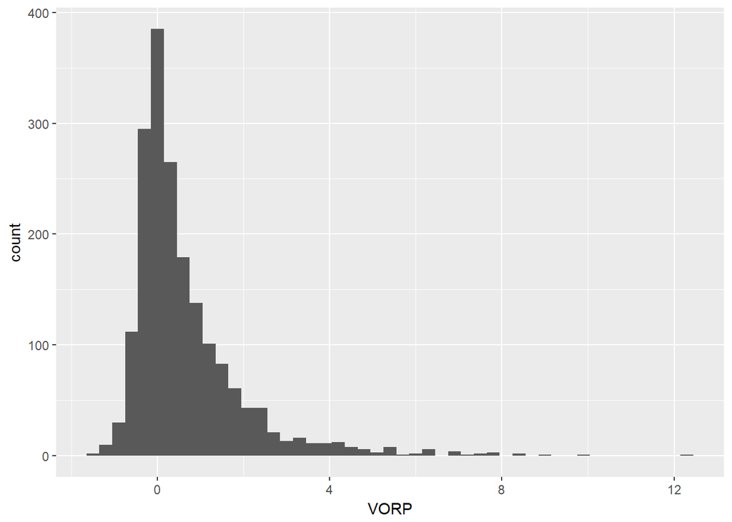

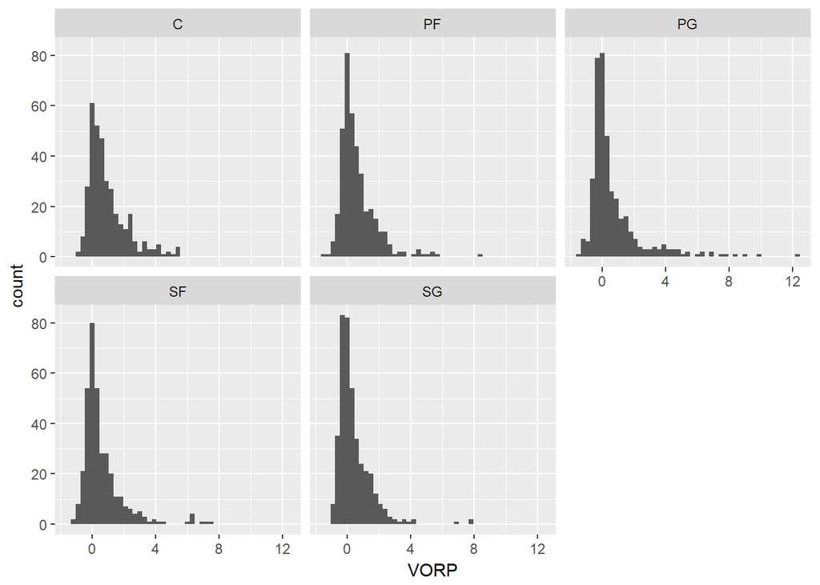

> Finally we look at VORP, another key advanced metric that measures value of a player relative to a replacement level player. The distribution of this metric produces a long tailed plot. While the distribution looks similar across the different positions, PGs seem to have the most values in the tail of the plot with quite a few players with a VORP over 4.

# Univariate Analysis

### What is/are the main feature(s) of interest in your dataset?

The main features I’m focusing on are PER and WR.48. These are the best metrics to determine a player’s overall value, I’d like to investigate how the other features affect these values, as well as looking at time series trends.

### What other features in the dataset do you think will help support your investigation into your feature(s) of interest?

I believe Pos and Age will be the categorical variables that have a significant impact on PER and WR.48. As far as other features that I want to look into how they affect the aforementioned variables, I’m interested in X3PA, X3PA, USG_PERC, TS., and VORP and discover others I might not have considered

### Did you create any new variables from existing variables in the dataset?

No

### Of the features you investigated, were there any unusual distributions? Did you perform any operations on the data to tidy, adjust, or change the form of the data? If so, why did you do this?

Yes. First thing I noticed was the presence of season stats entries that are based on too little minutes played (MP), greatly reducing the statistical significance of those season stats. Therefore I’ve replaced the working dataset with a subset only including entries with at least 250 minutes played. I’ve also noticed a few hybrid position with a very small number of entries. These hybrid positions add ‘clutter’ when performing analysis by positions, therefore I’ve reclassified them to a single position.

# Bivariate Plots Section

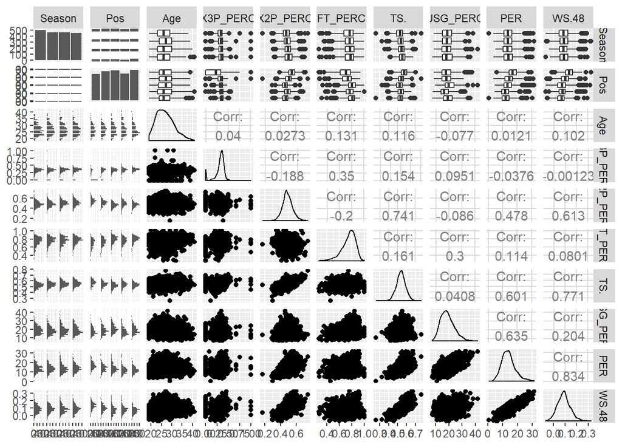

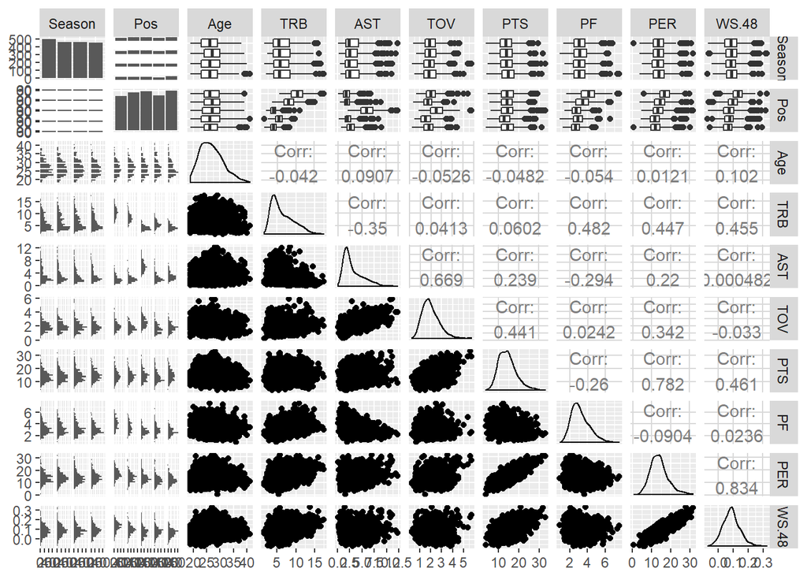

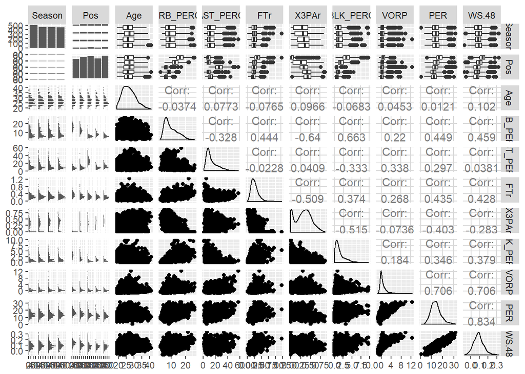

> I also would like to further investigate time series trends for some of the variables identified above.

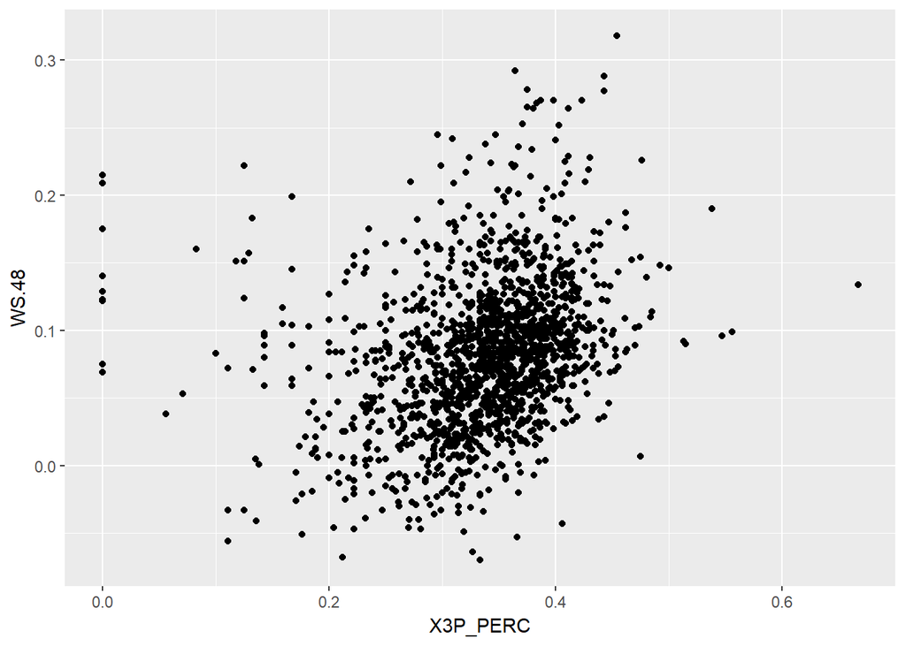

```
##    Min. 1st Qu.  Median    Mean 3rd Qu.    Max.    NA's
##  0.0000  0.2860  0.3385  0.3107  0.3750  1.0000     112
```

```
##
##  Pearson's product-moment correlation
##
## data:  subset(nba, X3PA > 0.286)$X3P_PERC and subset(nba, X3PA > 0.286)$WS.48
## t = 11.315, df = 1573, p-value < 2.2e-16
## alternative hypothesis: true correlation is not equal to 0
## 95 percent confidence interval:
##  0.2280352 0.3194038
## sample estimates:
##       cor
## 0.2743385
```

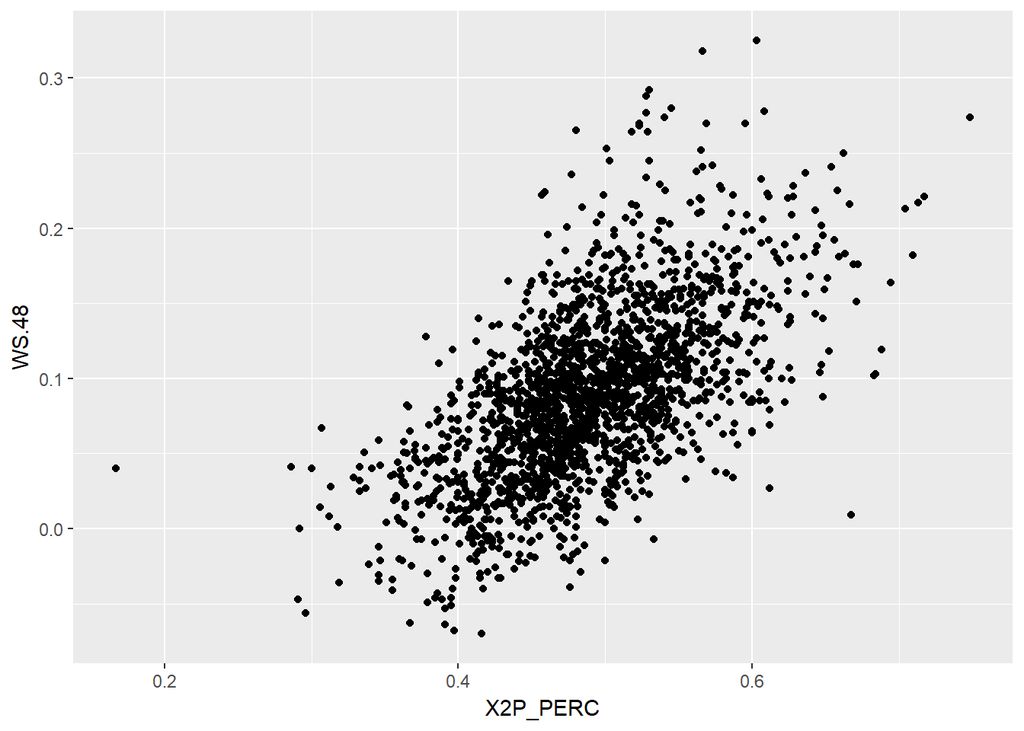

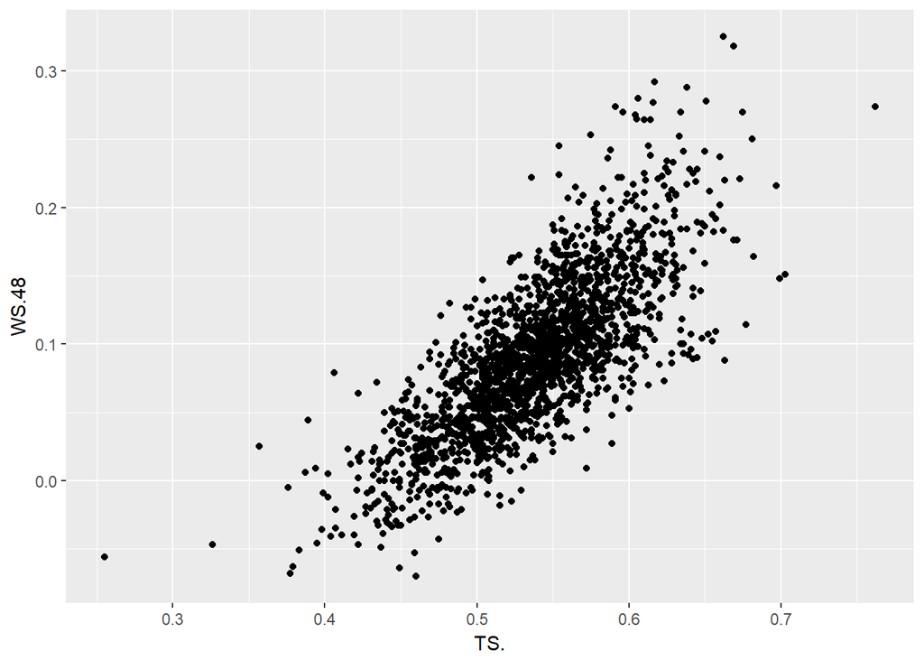

```
##
##  Pearson's product-moment correlation
##
## data:  nba$X2P_PERC and nba$WS.48
## t = 33.653, df = 1878, p-value < 2.2e-16
## alternative hypothesis: true correlation is not equal to 0
## 95 percent confidence interval:
##  0.5843332 0.6407801
## sample estimates:
##       cor
## 0.6133392
```

```
##
##  Pearson's product-moment correlation
##
## data:  nba$TS. and nba$WS.48
## t = 52.513, df = 1878, p-value < 2.2e-16
## alternative hypothesis: true correlation is not equal to 0
## 95 percent confidence interval:
##  0.7523025 0.7889776
## sample estimates:
##       cor
## 0.7712795
```

> As observed earlier this scatterplot shows the almost linear relationship and strong correlation between TS and WS.48. We should be able to draw a straight line fit through the plot:

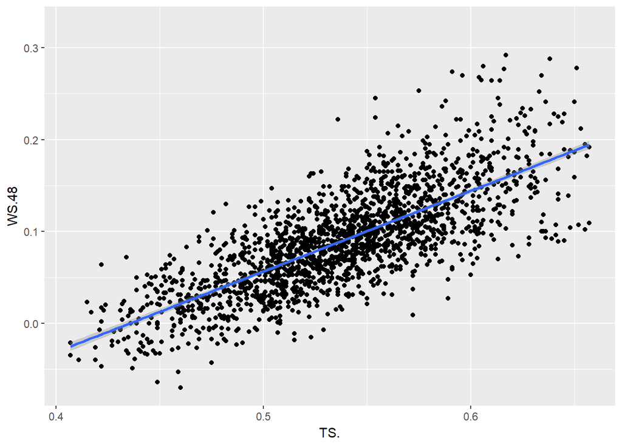

> The relationship is indeed linear between the 2 variables, I’m curious to see if teams have been working on constructing rosters with the mindset of increasing TS., next I’ll plot a time series of the median TS. over the last 4 seasons.

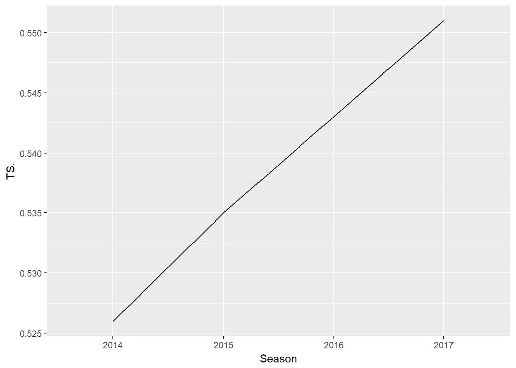

> Interesting, there has been a consistent steady improvement of the league TS. over the past 4 seasons, indicating an increasing emphasis on building rosters with a focus on TS.

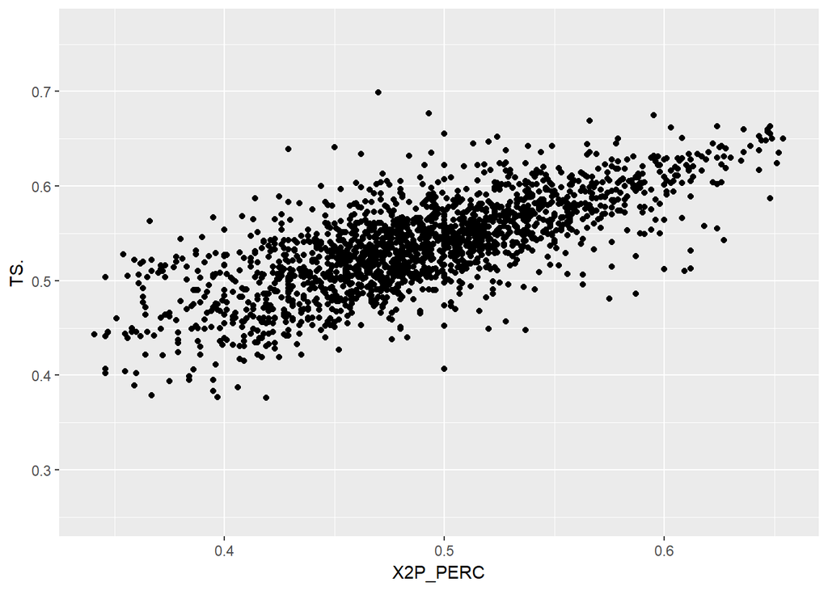